# Writing Functions in R (Chapter 4)

Advanced Inputs and Outputs

Seun Odeyemi

2019-06-27

# Dealing with failure

In this chapter we’ll start with tools for dealing with errors and then you’ll learn about variations on the types of inputs and outputs. One downside of map functions compared to for loops is that if one of the iteration fails, the whole thing fails. You don’t see any of the result up to that point. That can make using map functions quite frustrating. One way the `purrr` package helps us to deal with this issue is using the `safely()` function.

```r
safe_log <- safely(log)
```

`safely()` is like an adverb: it takes a function and returns a modified function that never throws an error. When we apply safely to log, the result is a new function. It’s called just like `log` but the return value is now a little different. Instead of returning a result or throw an error, a safe function always returns a list with two components: results and error. If the function worked, then result contains the result and the error is NULL otherwise, the result is NULL and the error component contains the error message.

```r
safe_log(10)
```

```
#> $result
#> [1] 2.302585
#>
#> $error
#> NULL
```

```r
safe_log("a")
```

```
#> $result
#> NULL
#>
#> $error
#> <simpleError in .Primitive("log")(x, base): non-numeric argument to mathematical function>
```

In the example above, `log(10)` will work without error so `safe_log(10)` returns a list with the result element containing the expected value i.e. the `log(10)` and the error value is NULL. log(“a”) will normally produce an error so the result element is NULL and the error element contains the error message. This structure is not always the most convenient in practice so in the exercises you’ll about the helpful transpose functions.

There are other purrr functions that work like `safely()`:

- `possibly()` always succeeds, but instead of returning a list you give it a default value to return when there is an error.
- `quietly()` captures printed output, messages, and warnings instead of capturing errors.

# Practice I

1. Creating a safe function

`safely()` is an adverb; it takes a verb and modifies it. That is, it takes a function as an argument and it returns a function as its output. The function that is returned is modified so it never throws an error (and never stops the rest of your computation!).

Instead, it always returns a list with two elements:

1. result is the original result. If there was an error, this will be NULL.
2. error is an error object. If the operation was successful this will be NULL.

Let’s try to make the `readLines()` function safe.

```r
# Create safe_readLines() by passing readLines() to safely()
safe_readLines <- safely(readLines)

# Call safe_readLines() on "http://example.org"
example_lines <- safe_readLines("http://example.org")
example_lines
```

```
#> $result
#>  [1] "<!doctype html>"
#>  [2] "<html>"
#>  [3] "<head>"
#>  [4] "    <title>Example Domain</title>"
#>  [5] ""
#>  [6] "    <meta charset=\"utf-8\" />"
#>  [7] "    <meta http-equiv=\"Content-type\" content=\"text/html; charset=utf-8\" />"
#>  [8] "    <meta name=\"viewport\" content=\"width=device-width, initial-scale=1\" />"
#>  [9] "    <style type=\"text/css\">"
#> [10] "    body {"
#> [11] "        background-color: #f0f0f2;"
#> [12] "        margin: 0;"
#> [13] "        padding: 0;"
#> [14] "        font-family: \"Open Sans\", \"Helvetica Neue\", Helvetica, Arial, sans-serif;"
```

[output cut: 39 more lines]

```r
# Call safe_readLines() on "http://asdfasdasdkfjlda"
nonsense_lines <- safe_readLines("http://asdfasdasdkfjlda")
nonsense_lines
```

```
#> $result
#> NULL
#>
#> $error
#> <simpleError in file(con, "r"): cannot open the connection>
```

2. Using map safely

One feature of safely() is that it plays nicely with the `map()` functions. Consider this list containing the two URLs from the last exercise, plus one additional URL to make things more interesting:

```r
urls <- list(
  example = "http://example.org",
  rproj = "https://www.r-project.org",
  asdf = "http://asdfasdasdkfjlda"
)
```

We are interested in quickly downloading the HTML files at each URL. You might try:

```r
map(urls, readLines) # returns an error
# Use the safe_readLines() function with map(): html
html <- map(urls, safe_readLines)
# Call str() on html
str(html)
```

```
#> List of 3
#>  $ example:List of 2
#>   ..$ result: chr [1:50] "<!doctype html>" "<html>" "<head>" "    <title>Example Domain</title>" ...
#>   ..$ error : NULL
#>  $ rproj  :List of 2
#>   ..$ result: chr [1:125] "<!DOCTYPE html>" "<html lang=\"en\">" "  <head>" "    <meta charset=\"utf-8\">" ...
#>   ..$ error : NULL
#>  $ asdf   :List of 2
#>   ..$ result: NULL
#>   ..$ error :List of 2
#>   .. ..$ message: chr "cannot open the connection"
#>   .. ..$ call   : language file(con, "r")
#>   .. ..- attr(*, "class")= chr [1:3] "simpleError" "error" "condition"
```

```r
# Extract the result from one of the successful elements
html$example[["result"]]
```

```
#>  [1] "<!doctype html>"
#>  [2] "<html>"
#>  [3] "<head>"
#>  [4] "    <title>Example Domain</title>"
#>  [5] ""
#>  [6] "    <meta charset=\"utf-8\" />"
#>  [7] "    <meta http-equiv=\"Content-type\" content=\"text/html; charset=utf-8\" />"
#>  [8] "    <meta name=\"viewport\" content=\"width=device-width, initial-scale=1\" />"
#>  [9] "    <style type=\"text/css\">"
#> [10] "    body {"
#> [11] "        background-color: #f0f0f2;"
#> [12] "        margin: 0;"
#> [13] "        padding: 0;"
#> [14] "        font-family: \"Open Sans\", \"Helvetica Neue\", Helvetica, Arial, sans-serif;"
#> [15] "        "
```

[output cut: 35 more lines]

```r
# Extract the error from the element that was unsuccessful
html$asdf[["error"]]
```

```
#> <simpleError in file(con, "r"): cannot open the connection>
```

3. Working with safe output

We now have output that contains the HTML for each of the two URLs on which readLines() was successful and the error for the other. But the output isn’t that easy to work with, since the results and errors are buried in the inner-most level of the list.

`purrr` provides a function `transpose()` that reshapes a list so the inner-most level becomes the outer-most level. In otherwords, it turns a list-of-lists “inside-out”. Consider the following list:

```r
nested_list <- list(
   x1 = list(a = 1, b = 2),
   x2 = list(a = 3, b = 4)
)
nested_list[["x1"]][["a"]]
```

```
#> [1] 1
```

```r
transpose(nested_list)[["a"]][["x1"]]
```

```
#> [1] 1
```

If I need to extract the a element in x1, I could do `nested_list[["x1"]][["a"]]`. However, if I transpose the list first, the order of subsetting reverses. That is, to extract the same element I could also do `transpose(nested_list)[["a"]][["x1"]]`.

This is really handy for safe output, since we can grab all the results or all the errors really easily.

```r
# Examine the structure of transpose(html)
str(transpose(html))
```

```
#> List of 2
#>  $ result:List of 3
#>   ..$ example: chr [1:50] "<!doctype html>" "<html>" "<head>" "    <title>Example Domain</title>" ...
#>   ..$ rproj  : chr [1:125] "<!DOCTYPE html>" "<html lang=\"en\">" "  <head>" "    <meta charset=\"utf-8\">" ...
#>   ..$ asdf   : NULL
#>  $ error :List of 3
#>   ..$ example: NULL
#>   ..$ rproj  : NULL
#>   ..$ asdf   :List of 2
#>   .. ..$ message: chr "cannot open the connection"
#>   .. ..$ call   : language file(con, "r")
#>   .. ..- attr(*, "class")= chr [1:3] "simpleError" "error" "condition"
```

```r
# Extract the results: res
res <- transpose(html)[["result"]]
# Extract the errors: errs
errs <- transpose(html)[["error"]]
```

4. Working with errors and results

What you do with the errors and results is up to you. But, commonly you’ll want to collect all the results for the elements that were successful and examine the inputs for all those that weren’t.

```r
# Create a logical vector is_ok
is_ok <- map_lgl(.x = errs, .f = is.null)

# Extract the successful results
res[is_ok]
```

```
#> $example
#>  [1] "<!doctype html>"
#>  [2] "<html>"
#>  [3] "<head>"
#>  [4] "    <title>Example Domain</title>"
#>  [5] ""
#>  [6] "    <meta charset=\"utf-8\" />"
#>  [7] "    <meta http-equiv=\"Content-type\" content=\"text/html; charset=utf-8\" />"
#>  [8] "    <meta name=\"viewport\" content=\"width=device-width, initial-scale=1\" />"
#>  [9] "    <style type=\"text/css\">"
#> [10] "    body {"
#> [11] "        background-color: #f0f0f2;"
#> [12] "        margin: 0;"
#> [13] "        padding: 0;"
#> [14] "        font-family: \"Open Sans\", \"Helvetica Neue\", Helvetica, Arial, sans-serif;"
```

[output cut: 163 more lines]

```r
# Find the URLs that were unsuccessful
urls[!is_ok]
```

```
#> $asdf
#> [1] "http://asdfasdasdkfjlda"
```

# Maps over multiple arguments

So far we’ve iterated over only one argument per function. Over the next set of exercises, we’ll learn functions in purrr that allow us to iterate over more than one argument. A running example throughout the following section is generating random samples from known statistical distributions. For example, the `rnorm()` function draws a random sample from a normal distribution:

```r
rnorm(n, mean = 0, sd = 1)
```

```
#> Error in rnorm(n, mean = 0, sd = 1): object 'n' not found
```

- The first argument `n` specifies the size of the sample.
- `mean` and `sd` specifies the `mean` and `sd` of the normal distribution.

Imagine, we want to take three samples of size 5, 10, and 20. We could write three calls to rnorm. Or, we can use our new `map` skills to write one call.

```r
# Three calls to rnorm
rnorm(5)
```

```
#> [1]  0.7046781 -0.4891562 -1.6386258 -0.5314929  0.1669896
```

```r
rnorm(10)
```

```
#>  [1] -0.2014411  0.9340227  0.1337432  0.2264778 -0.6099753 -0.5831232
#>  [7]  0.3880761  1.9145118 -0.7934429  0.3873162
```

```r
rnorm(20)
```

```
#>  [1] -1.17937072  1.34472409  0.83096163 -1.72063063 -2.22850894
#>  [6] -0.96635314  1.66445154 -1.30715693 -0.86234213 -0.72711550
#> [11] -0.36629648  0.15875682  1.30217925  0.11650446 -1.19260630
#> [16]  0.02730325 -0.07030570 -0.24101122  0.31405184 -0.56116044
```

```r
# One call to rnorm
map(list(5, 10, 20), rnorm)
```

```
#> [[1]]
#> [1] 1.8261359 0.0768458 1.1948641 0.1752312 0.7295664
#>
#> [[2]]
#>  [1] -0.6075754  1.5248230 -0.8579145 -0.7369159 -0.2944359 -0.6179230
#>  [7]  2.6167406 -1.1775453 -2.3585885 -1.0393394
#>
#> [[3]]
#>  [1]  1.92109141  0.47887042  1.90740393 -0.05279429 -1.03463662
#>  [6] -2.42802641  0.63295966 -0.32144247 -0.88433071  1.26497020
#> [11]  1.19112522  0.22763655 -0.63664629  0.44982963  1.24837484
#> [16]  0.54395549  1.47092703 -0.71078587  0.10762053  0.54831319
```

We map over a list of sample sizes 5, 10, 20 each time applying the function, `rnorm`. What if we wanted to vary the mean of the normal distribution for each sample. For example, the sample of size 5 should come from a mean 1; sample of size 10 from mean 5; and sample of size 20 from mean 10. The `purrr` function, `map2()` is designed exactly for this iteration problem. map2 has an additional argument, `.y` that allows us to specify another object to iterate over. The function, `.f` is applied over the first element of both `.x` and `.y`then `.f` is applied over the second element of both `.x` and `.y`, and so on until it has iterated through the list.

```r
map2(.x = list(5, 10, 20), .y = list(1, 5, 10), .f = rnorm)
```

```
#> [[1]]
#> [1]  0.85606274  0.63954454  0.96695249 -0.15432703 -0.06233467
#>
#> [[2]]
#>  [1] 5.182832 5.386081 4.902409 6.717921 2.922245 5.005945 4.366877
#>  [8] 3.285143 4.567569 3.851562
#>
#> [[3]]
#>  [1]  9.539862 10.920305 10.164942 10.683932 10.550897  9.749066  9.668562
#>  [8] 10.100319 10.616462  9.840813 10.916394 12.189057  9.573837 10.962264
#> [15] 10.114428  9.616812  9.846673  9.855515 10.287399 10.888336
```

For this example, we supplied the samples sizes as `.x`, the means as `.y`, and then we applied the rnorm function in `.f`. Let’s take it a step further: what if the `sd` argument should also vary across the sample sizes? Now, we have three arguments to iterate over. Rather, than having map3 and map4, and so on, purrr provides the `pmap()` function, which handles iterating over many arguments.

The first argument to pmap is a list .l, that should contain all the lists to iterate over. For example, if you need to iterate over two arguments, there should be two lists inside .l. For our current example, .l needs to be a list with three arguments: a list of the sample sizes; means; and standard deviations. Using names for these lists ensures that the values are matched up to the right argument in the function we are iteratively applying.

```r
pmap(list(n = list(5, 10, 20),
          mean = list(1, 5, 10),
          sd = list(0.1, 0.5, 0.1)), rnorm)
```

```
#> [[1]]
#> [1] 1.0015437 0.9822256 0.9715276 1.2392364 0.8837048
#>
#> [[2]]
#>  [1] 3.839316 4.672914 4.408590 5.103388 5.002161 5.578660 5.054191
#>  [8] 5.292509 4.731109 4.201088
#>
#> [[3]]
#>  [1] 10.082740 10.144350  9.844008 10.077436  9.958727  9.928956 10.036374
#>  [8] 10.045479  9.944279 10.021780  9.920193  9.928331 10.111688  9.919957
#> [15]  9.824246  9.936928  9.903681  9.937474  9.950165 10.096025
```

Finally, you might want to iterate not over a vector of values, but over functions themselves. For example, we might be interested in simulating over different distributions: normal, uniform, and exponential. This is handled in purrr by the `invoke_map()` function. Since, we now want to iterate over functions, the order of the argument in invoke_map() is reversed: .f comes first and should be a list of functions, .x is second as a list where we can specify arguments for each function in .f. In our example, all the functions take the same argument, n = 5, so we can pass that through the . . . argument. Here, each of rnorm, runif, and rexp are been called with the sample size of 5.

```r
invoke_map(list(rnorm, runif, rexp), n = 5)
```

```
#> [[1]]
#> [1]  1.3044049  0.7189225 -0.5927020  0.6778884 -0.8180872
#>
#> [[2]]
#> [1] 0.07456594 0.34899762 0.99097968 0.82199520 0.31666454
#>
#> [[3]]
#> [1] 0.08361723 0.85844862 1.66212929 1.50927612 1.82820015
```

In summary, purrr provides:

- `map2()` for iterating over two arguments.
- `pmap()` for iterating over two or more arguments
- `invoke_map()` for iterating over functions and arguments.
- Like `map()`, each has a whole family of functions: `map2_dbl()`, `map2_lgl()`, `pmap_dbl()`, etc.

# Practice II

1. Getting started

```r
# Create a list n containing the values: 5, 10, and 20
n <- list(5, 10, 20)
# Call map() on n with rnorm() to simulate three samples
map(.x = n, .f = rnorm)
```

```
#> [[1]]
#> [1] -0.1161573 -0.2763827 -1.0063503  0.4205481 -1.6271376
#>
#> [[2]]
#>  [1] -1.46657185  0.67442684 -1.20288172  0.71324860 -1.14244870
#>  [6]  1.09475622  2.75202695  1.42873178  1.22159856 -0.02713957
#>
#> [[3]]
#>  [1] -1.04214576 -0.93026759  0.01741052 -1.62201629  0.84521388
#>  [6] -2.65522064 -1.63634402 -0.94991386 -0.69412888 -0.56843551
#> [11]  1.31971550 -1.54055802 -1.46432361 -0.39306113 -0.46362735
#> [16]  0.61791613 -0.14998609  1.03850076 -1.27224265 -1.58556701
```

2. Mapping over two arguments

Ok, but now imagine we don’t just want to vary the sample size, we also want to vary the mean. The mean can be specified in `rnorm()` by the argument `mean`. Now there are two arguments to `rnorm()` we want to vary: `n` and `mean`.

The `map2()` function is designed exactly for this purpose; it allows iteration over two objects. The first two arguments to map2() are the objects to iterate over and the third argument .f is the function to apply.

Let’s use `map2()` to simulate three samples with different sample sizes and different means.

```r
# Initialize n
n <- list(5, 10, 20)

# Create a list mu containing the values: 1, 5, and 10
mu <- list(1, 5, 10)

# Edit to call map2() on n and mu with rnorm() to simulate three samples
map2(.x = n, .y = mu, .f = rnorm)
```

```
#> [[1]]
#> [1] -0.05568926  1.21242225  2.30560544  0.46302403 -0.70543011
#>
#> [[2]]
#>  [1] 6.374101 4.251782 5.721108 5.463422 4.069425 5.041678 4.665648
#>  [8] 6.851659 5.741930 4.497596
#>
#> [[3]]
#>  [1] 10.170846  8.184000 10.249026 10.389180 11.031947 10.735457  9.113282
#>  [8] 10.953501 10.930989  9.080041  9.843495 10.438600 10.933182  9.144831
#> [15]  9.964916  9.971337  8.948887  9.542343  8.507127  9.243226
```

3. Mapping over more than two arguments

But wait, there’s another argument to `rnorm()` we might want to vary: `sd`, the standard deviation of the Normal distribution. You might think there is a `map3()` function, but there isn’t. Instead `purrr` provides a `pmap()` function that iterates over 2 or more arguments.

First, let’s take a look at `pmap()` for the situation we just solved: iterating over two arguments. Instead of providing each item to iterate over as arguments, pmap() takes a list of arguments as its input. For example, we could replicate our previous example, iterating over both n and mu with the following:

```r
n <- list(5, 10, 20)
mu <- list(1, 5, 10)

pmap(list(n, mu), rnorm)
```

```
#> [[1]]
#> [1] 2.41405196 0.10830387 0.05945395 0.61970935 0.30169859
#>
#> [[2]]
#>  [1] 5.248521 6.251064 5.963891 5.229406 3.241856 5.827631 4.307824
#>  [8] 5.481850 5.707253 3.616813
#>
#> [[3]]
#>  [1] 10.162070 10.501171 10.472611  9.821124  8.573487 10.039068 10.635085
#>  [8]  7.657309 11.102312 10.377337 10.419900  9.059731  8.483569 10.388632
#> [15] 11.340236 10.123126 11.374226 10.947536 11.036501  9.477384
```

Notice how we had to put our two items to iterate over (n and mu) into a list.

Let’s expand this code to iterate over varying standard deviations too.

```r
# Initialize n and mu
n <- list(5, 10, 20)
mu <- list(1, 5, 10)

# Create a sd list with the values: 0.1, 1 and 0.1
sd <- list(0.1, 1, 0.1)

# Edit this call to pmap() to iterate over the sd list as well
pmap(.l = list(n, mu, sd), .f = rnorm)
```

```
#> [[1]]
#> [1] 0.9510899 0.9555454 1.0051262 0.9409924 0.9875070
#>
#> [[2]]
#>  [1] 2.954289 4.793443 4.247926 4.175862 2.383662 4.347598 4.179261
#>  [8] 6.431058 5.290648 5.229875
#>
#> [[3]]
#>  [1]  9.951806  9.968956 10.023910  9.918692 10.003077 10.197679 10.138056
#>  [8] 10.178463  9.929970  9.936604  9.905595  9.990513  9.970739 10.076536
#> [15] 10.088727 10.011891 10.134107 10.014920 10.154165  9.976461
```

4. Argument matching

Compare the following two calls to `pmap()` (run them in the console and compare their output too!):

```r
pmap(list(n, mu, sd), rnorm)
```

```
#> [[1]]
#> [1] 0.9645265 0.9226952 1.1635046 1.0118362 1.0325850
#>
#> [[2]]
#>  [1] 6.073016 4.761398 5.394693 5.373829 3.128438 5.601969 4.193079
#>  [8] 5.140933 4.932038 5.305493
#>
#> [[3]]
#>  [1] 10.038870  9.990136 10.064220 10.027256  9.927245 10.043160  9.952682
#>  [8] 10.018680 10.140453  9.888277  9.987236 10.155708  9.829816 10.055148
#> [15] 10.169305 10.076906  9.868219  9.926215  9.978646 10.085648
```

```r
pmap(list(mu, n, sd), rnorm)
```

```
#> [[1]]
#> [1] 4.987463
#>
#> [[2]]
#> [1]  8.508151 10.878703  9.858482  9.083146  7.901465
#>
#> [[3]]
#>  [1] 19.91458 19.99262 20.03831 19.99107 20.07151 19.94492 19.99499
#>  [8] 20.19353 19.92694 20.03151
```

What’s the difference? By default `pmap()` matches the elements of the list to the arguments in the function by position. In the first case, `n` to the `n` argument of `rnorm()`, `mu` to the `mean` argument of `rnorm()`, and `sd` to the `sd` argument of `rnorm()`. In the second case `mu` gets matched to the `n` argument of `rnorm()`, which is clearly not what we intended!

Instead of relying on this positional matching, a safer alternative is to provide names in our list. The name of each element should be the argument name we want to match it to.

Let’s fix up that second call.

```r
# Name the elements of the argument list
pmap(.l = list(mean = mu, n = n, sd = sd), .f = rnorm)
```

```
#> [[1]]
#> [1] 0.9840712 1.2034781 1.0714408 0.9114465 0.9799691
#>
#> [[2]]
#>  [1] 5.049396 5.439589 4.136760 5.037584 4.459706 5.011827 4.215377
#>  [8] 4.613503 3.932940 4.620973
#>
#> [[3]]
#>  [1] 10.028398 10.010913 10.009800 10.083834  9.995930  9.907453  9.870938
#>  [8] 10.007706  9.801819 10.010303  9.912318  9.903358 10.055334  9.940394
#> [15]  9.976369  9.973676  9.941843 10.002674 10.030959  9.853000
```

5. Mapping over functions and their arguments

Sometimes it’s not the arguments to a function you want to iterate over, but a set of functions themselves. Imagine that instead of varying the parameters to `rnorm()` we want to simulate from different distributions, say, using `rnorm()`, `runif()`, and `rexp()`. How do we iterate over calling these functions?

In `purrr`, this is handled by the `invoke_map()` function. The first argument is a list of functions. In our example, something like:

```r
funs <- list("rnorm", "runif", "rexp")
```

The second argument specifies the arguments to the functions. In the simplest case, all the functions take the same argument, and we can specify it directly, relying on `...` to pass it to each function. In this case, call each function with the argument `n = 5`:

```r
invoke_map(funs, n = 5)
```

```
#> [[1]]
#> [1] -0.4942484 -0.4381177  1.5088975  0.6848968 -1.0867451
#>
#> [[2]]
#> [1] 0.2164979 0.6042275 0.5609462 0.6757446 0.7484121
#>
#> [[3]]
#> [1] 2.6377199 1.2887492 0.3297207 0.8724294 1.3169711
```

In more complicated cases, the functions may take different arguments, or we may want to pass different values to each function. In this case, we need to supply `invoke_map()` with a list, where each element specifies the arguments to the corresponding function.

Let’s use this approach to simulate three samples from the following three distributions: `Normal(10, 1)`, `Uniform(0, 5)`, and `Exponential(5)`.

```r
# Define list of functions
funs <- list("rnorm", "runif", "rexp")

# Parameter list for rnorm()
rnorm_params <- list(mean = 10)

# Add a min element with value 0 and max element with value 5
runif_params <- list(min = 0, max = 5)

# Add a rate element with value 5
rexp_params <- list(rate = 5)

# Define params for each function
params <- list(
  rnorm_params,
  runif_params,
  rexp_params
)

# Call invoke_map() on funs supplying params and setting n to 5
invoke_map(funs, params, n = 5)
```

```
#> [[1]]
#> [1] 11.280026 10.159494  9.972494 10.176852 10.867800
#>
#> [[2]]
#> [1] 3.803608 3.841255 3.248950 4.011122 2.817564
#>
#> [[3]]
#> [1] 0.01657079 0.03839640 0.24981922 0.72922049 0.47827382
```

# Maps with side effects

Some functions in R aren’t called for their return value, but are called for their side effects instead. In this video we’ll introduce the walk functions: the functions in purrr designed to be used for their side effects. What are side effects? A side effect describes anything that happens that isn’t in the return value of the function. Examples include: printing output, plotting, and saving files. In purrr, the `walk()` function is just like `map()` except it is designed for iterating functions called for their side effects. The usage is identical: .x contains the object to be iterated over and .f is the function to be applied to each element.

```r
# walk(.x, .f)
x <- list(1, "a", 3)
x %>% walk(print)
```

```
#> [1] 1
#> [1] "a"
#> [1] 3
```

In the above example, we created a list `x` containing a mix of numeric and character elements. We then piped (%>%) x into the `walk()` function using `print` as the argument. Remember, this is equivalent to calling `walk(x, print)`. The result is the side effect iterated over every element of `.x`. In this case, each element of .x is printed to the screen. Walking more interesting when you iterate over two or more arguments. Just like map, there are `walk2()` and `pwalk()` functions designed for this purpose.

Let’s take a look at a more interesting example. Here we use the `ggplot2` package to create a list of plots. We also create a list of path names—file names we might to use for the pdf versions of these plots. Then, we can use walk2 to iterate over our list of plots and list of paths each time applying the function `ggsave`: another ggplot2 function that takes the description of a plot and saves it to disk.

```r
library(ggplot2)
plots <- cyl %>%
  map(~ ggplot(., aes(mpg, wt)) + geom_point())
```

```
#> Error in eval(lhs, parent, parent): object 'cyl' not found
```

```r
paths <- paste0(names(plots), ".pdf")
```

```
#> Error in paste0(names(plots), ".pdf"): object 'plots' not found
```

```r
walk2(paths, plots, ggsave)
```

```
#> Error in map2(.x, .y, .f, ...): object 'paths' not found
```

Since the return value of the functions called for their side effects isn’t generally of interest. There are no variance like walk_dbl or walk_lgl for different return types instead always returns the original input of .x unchanged. This makes `walk()` usable in pipelines. In this example below, we first *walk* x using print to see the object inside each element, then we map x using `length()` to the find the length of each object. In one line, we’ve found the length and taking a peek at the contents

```r
lengths <- x %>% walk(print) %>% map_dbl(length)
```

```
#> [1] 1
#> [1] "a"
#> [1] 3
```

```r
lengths
```

```
#> [1] 1 1 1
```

# Practice III

1. Walk

`walk()` operates just like `map()` except it’s designed for functions that don’t return anything. You use `walk()` for functions with side effects like printing, plotting or saving.

Let’s check that our simulated samples are in fact what we think they are by plotting a histogram for each one.

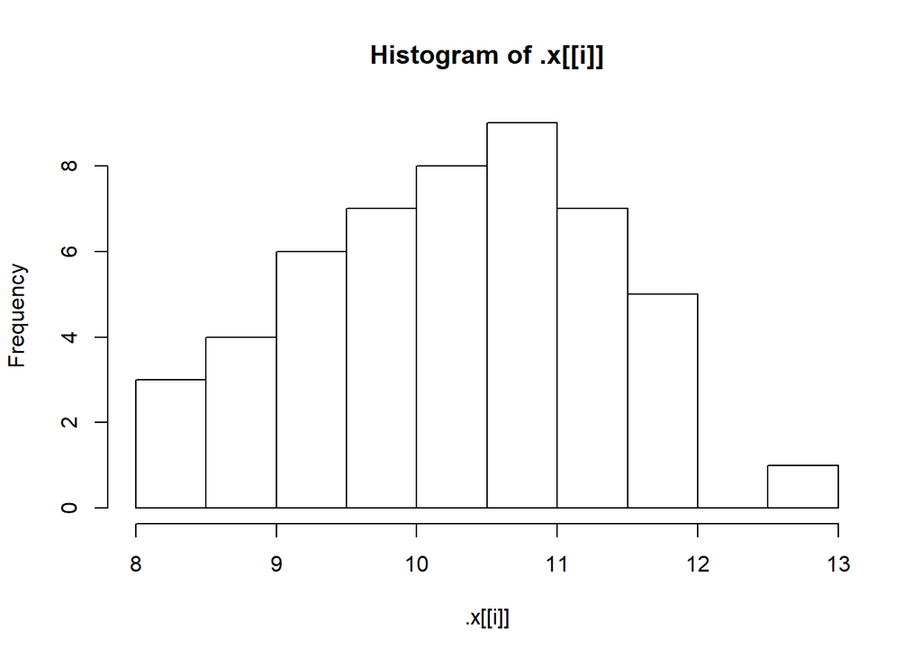

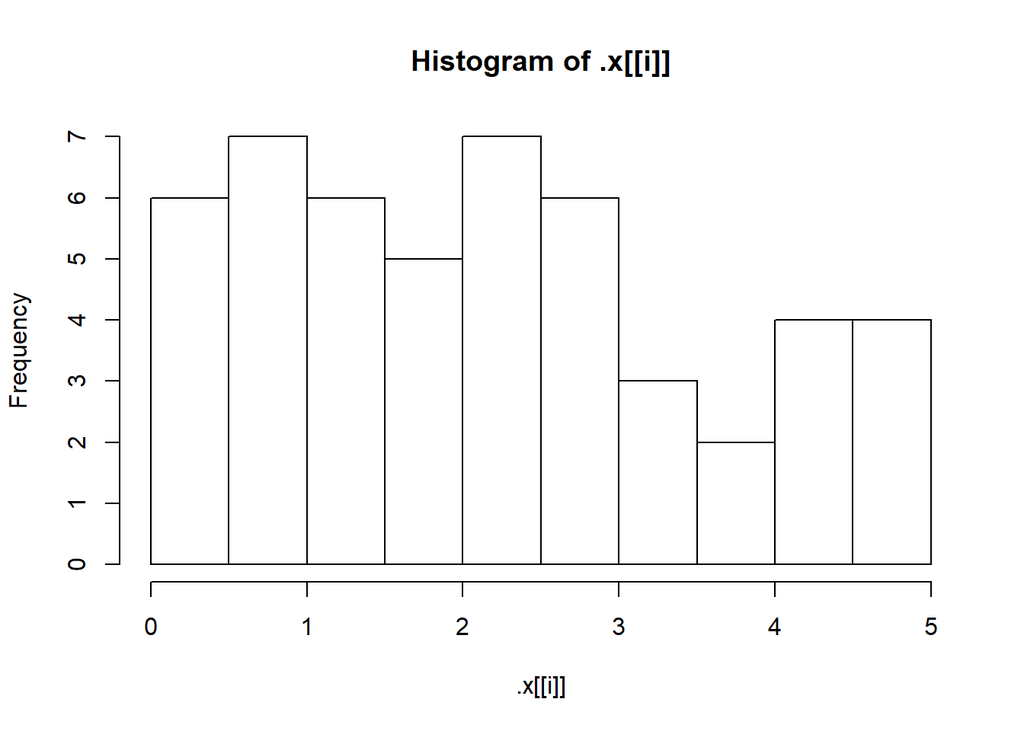

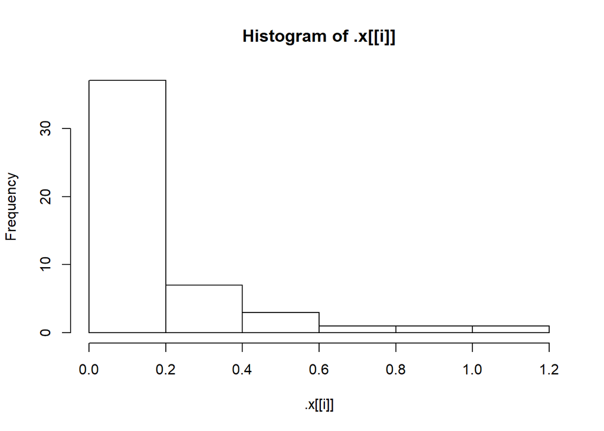

```r
# Define list of functions
funs <- list(Normal = "rnorm", Uniform = "runif", Exp = "rexp")

# Define params
params <- list(
  Normal = list(mean = 10),
  Uniform = list(min = 0, max = 5),
  Exp = list(rate = 5)
)

# Assign the simulated samples to sims
sims <- invoke_map(.f = funs, .x = params, n = 50)

# Use walk() to make a histogram of each element in sims
sims %>% walk(hist)
```

Great work! Take a quick look through the three histograms, do they have any problems?

2. Walking over two or more arguments

Those histograms were pretty good, but they really needed better breaks for the bins on the x-axis. That means we need to vary two arguments to `hist()`: `x` and `breaks`. Remember `map2()`? That allowed us to iterate over two arguments. Guess what? There is a `walk2()`, too!

Let’s use `walk2()` to improve those histograms with better breaks.

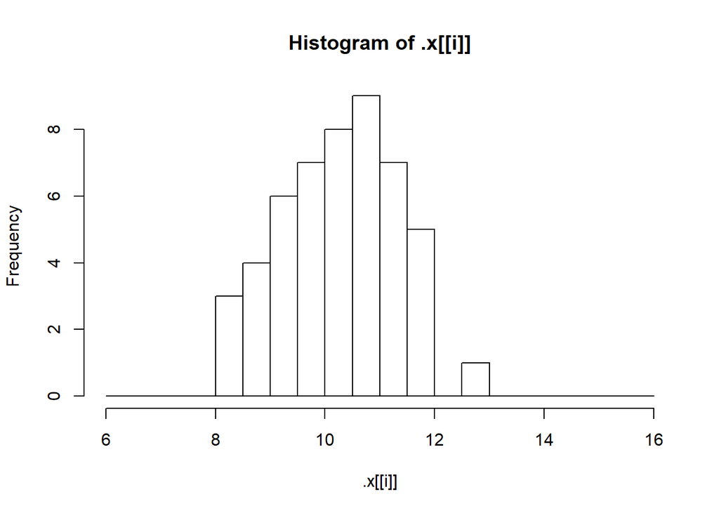

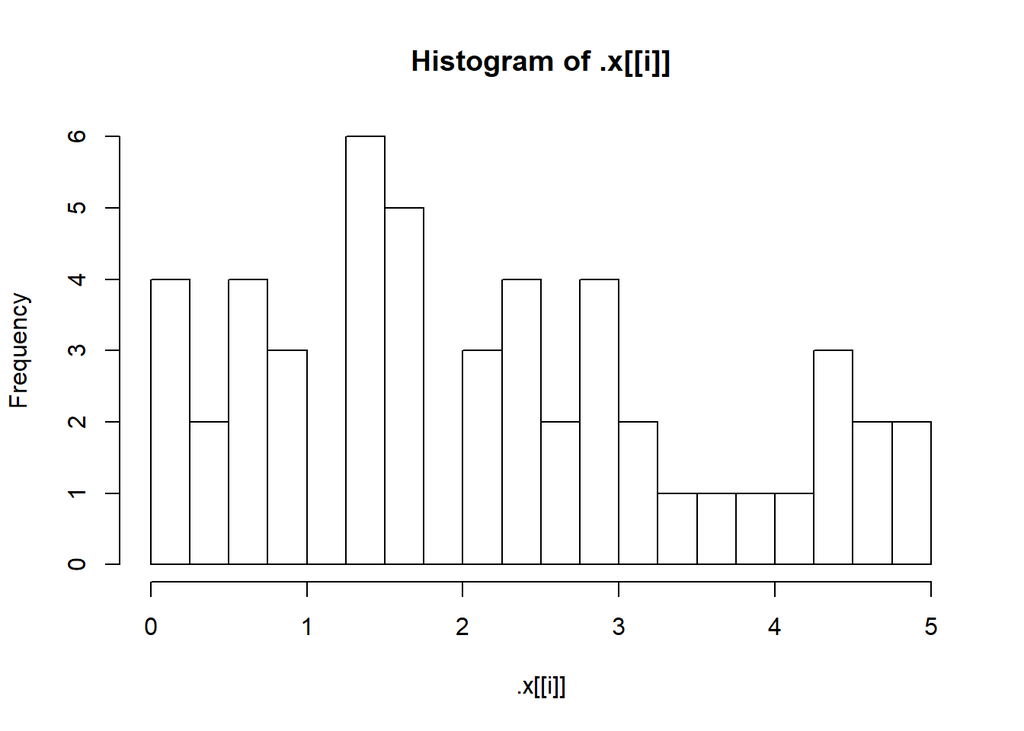

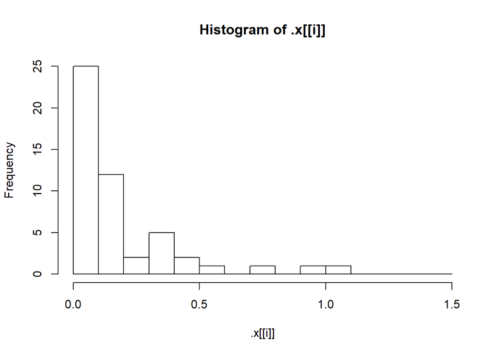

```r
# Replace "Sturges" with reasonable breaks for each sample
breaks_list <- list(
  Normal = seq(6, 16, 0.5),
  Uniform = seq(0, 5, 0.25),
  Exp = seq(0, 1.5, 0.1)
)

# Use walk2() to make histograms with the right breaks
sims %>% walk2(breaks_list, hist)
```

Awesome job! Don’t worry about those ugly labels. We’ll fix them later.

3. Putting together writing functions and walk

In the previous exercise, we hard-coded the breaks, but that was a little lazy. Those breaks probably won’t be great if we change the parameters of our simulation.

A better idea would be to generate reasonable breaks based on the actual values in our simulated samples. This is a great chance to review our function writing skills and combine our own function with purrr.

Let’s start by writing our own function find_breaks(), which copies the default breaks in the ggplot2 package: break the range of the data in 30 bins.

How do we start? Simple, of course! Here’s a snippet of code that works for the first sample:

```r
rng <- range(sims[[1]], na.rm = TRUE)
seq(rng[1], rng[2], length.out = 30)
```

```
#>  [1]  8.258969  8.413443  8.567916  8.722390  8.876863  9.031337  9.185810
#>  [8]  9.340284  9.494758  9.649231  9.803705  9.958178 10.112652 10.267125
#> [15] 10.421599 10.576072 10.730546 10.885019 11.039493 11.193966 11.348440
#> [22] 11.502914 11.657387 11.811861 11.966334 12.120808 12.275281 12.429755
#> [29] 12.584228 12.738702
```

Your job in this exercise is to turn that snippet into a function.

In the next exercise, we’ll combine `find_breaks()` with `map()` and `walk2()` to create histograms with sensible breaks.

```r
# Turn this snippet into find_breaks()
find_breaks <- function(x){
  rng <- range(x, na.rm = TRUE)
  seq(rng[1], rng[2], length.out = 30)
}

# Call find_breaks() on sims[[1]]
find_breaks(sims[[1]])
```

```
#>  [1]  8.258969  8.413443  8.567916  8.722390  8.876863  9.031337  9.185810
#>  [8]  9.340284  9.494758  9.649231  9.803705  9.958178 10.112652 10.267125
#> [15] 10.421599 10.576072 10.730546 10.885019 11.039493 11.193966 11.348440
#> [22] 11.502914 11.657387 11.811861 11.966334 12.120808 12.275281 12.429755
#> [29] 12.584228 12.738702
```

4. Nice breaks for all

Now that we have `find_breaks()`, we can find nice breaks for all the samples using `map()`. Then, pass the result into `walk2()` to get nice (but custom breaks) for our samples.

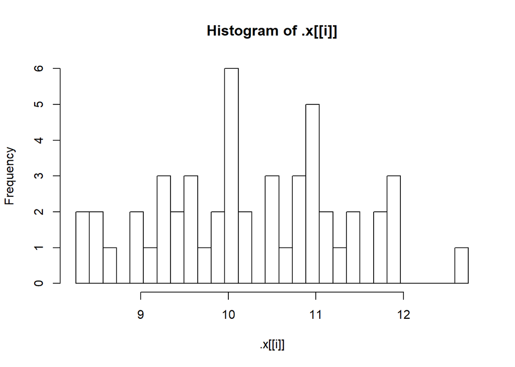

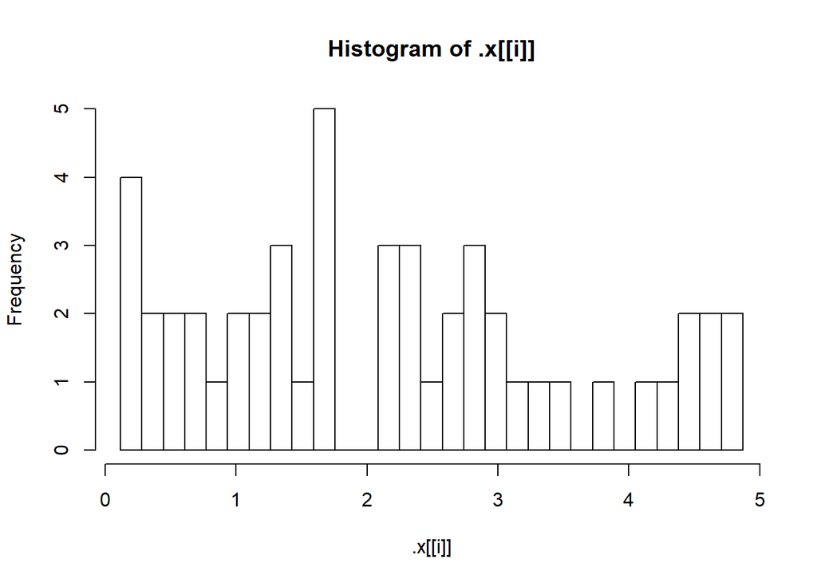

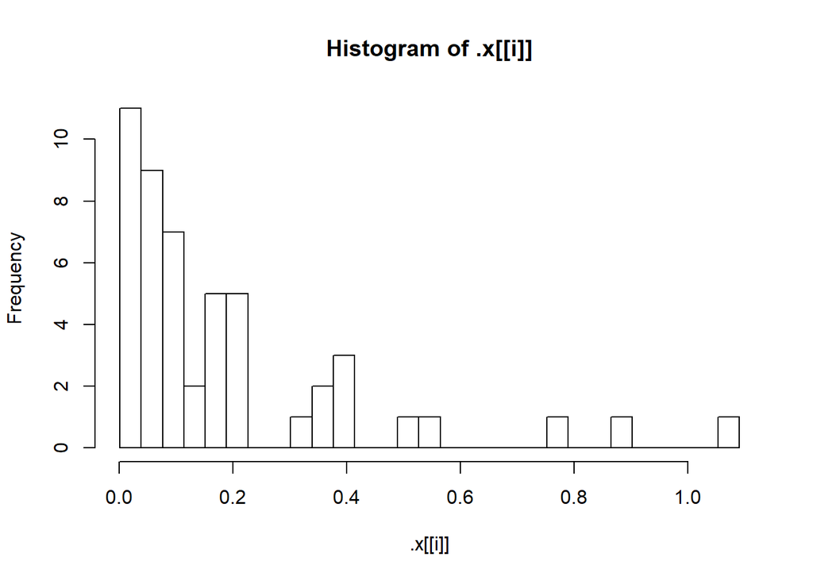

```r
# Use map() to iterate find_breaks() over sims: nice_breaks
nice_breaks <- sims %>% map(find_breaks)

# Use nice_breaks as the second argument to walk2()
sims %>% walk2(nice_breaks, hist)
```

5. Walking with many arguments: pwalk

Ugh! Nice breaks but those plots had UUUUGLY labels and titles. The x-axis labels are easy to fix if we don’t mind every plot having its x-axis labeled the same way. We can use the `...` argument to any of the `map()` or `walk()` functions to pass in further arguments to the function `.f`. In this case, we might decide we don’t want any labels on the x-axis, in which case we need to pass an empty string to the `xlab` argument of `hist()`:

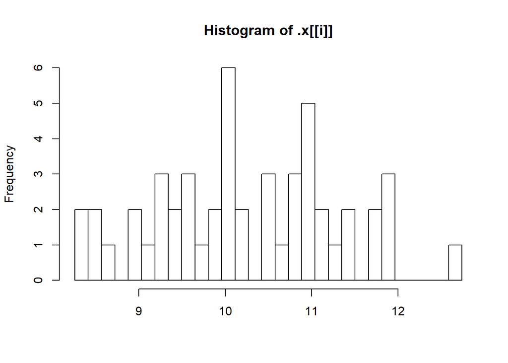

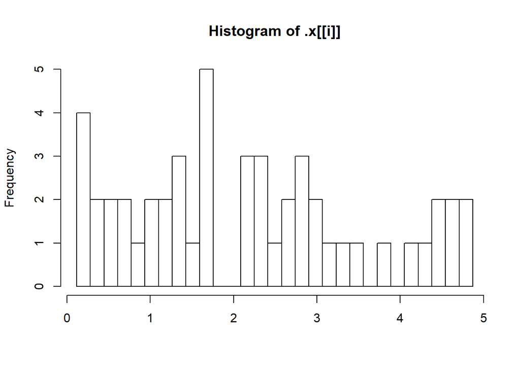

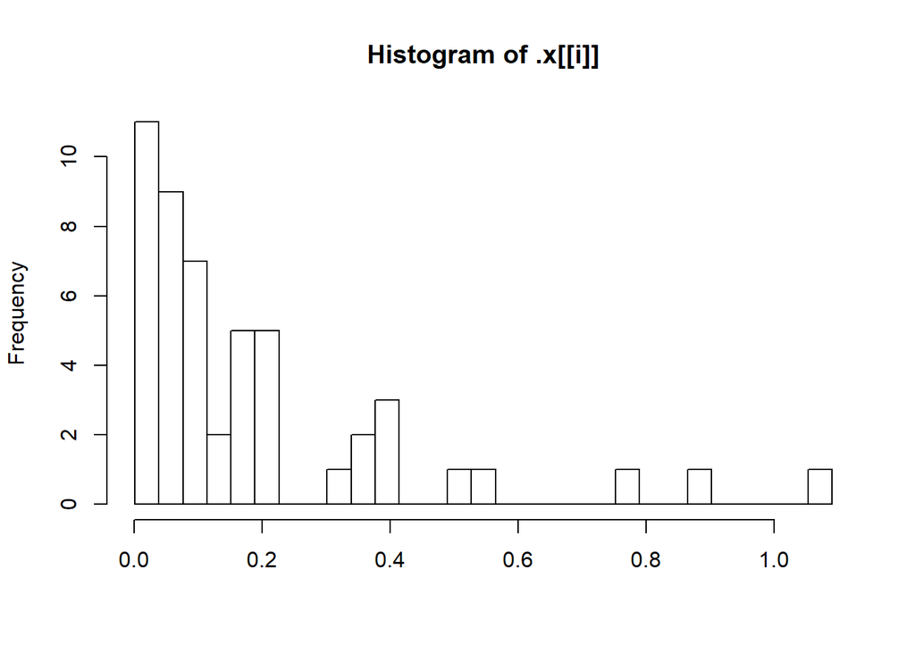

```r
walk2(sims, nice_breaks, hist, xlab = "")
```

But, what about the titles? We don’t want them to be the same for each plot. How can we iterate over the arguments `x`, `breaks` and `main`? You guessed it, there is a `pwalk()` function that works just like pmap().